# Practical Machine Learning Project

Xinyi Zhao

March 3, 2018

People regularly do is quantify how much of a particular activity they do, but they rarely quantify how well they do it. To predict the manner in which people did the exercise, we used data from accelerometers on the belt, forearm, arm, and dumbell of 6 participants to build a prediction model and to perform cross-validation.

# Data Source

The data for this project was from: http://web.archive.org/web/20161224072740/http:/groupware.les.inf.puc-rio.br/har. For more information about the dataset, please see the section on the Weight Lifting Exercise Dataset.

To ensure the quality of prediction, we removed the variables with any missing value. And to perform cross-validation, we splited the training dataset into two datasets – 60% as a training dataset, and the rest 40% as a testing dataset.

```r
set.seed(56871)
# set working directory and load data
setwd("C:/Users/Hitomi/Dropbox/Keep Smile!/coursera/practical_machine_learning")
library(caret)
library(rattle)
```

```r
library(rpart)
library(rpart.plot)
library(randomForest)
library(repmis)
library(e1071)
training <- read.csv("pml-training.csv", na.strings = c("NA", ""))
testing <- read.csv("pml-testing.csv", na.strings = c("NA", ""))
#str(training)
#str(testing)

# The first column is not meaningful, so we remove it
training <- training[-c(1)]
testing <- testing[-c(1)]

# Remove variables that have missing data
training <- training[, colSums(is.na(training)) == 0]
testing <- testing[, colSums(is.na(testing)) == 0]

# Split the training dataset into two
inTrain <- createDataPartition(training$classe, p=0.6, list=FALSE)
myTraining <- training[inTrain, ]
myTesting <- training[-inTrain, ]
```

# Prediction Models

We tried two different methods to build the prediction model – (1) decision trees and (2) random forests

## (1) Decision Trees

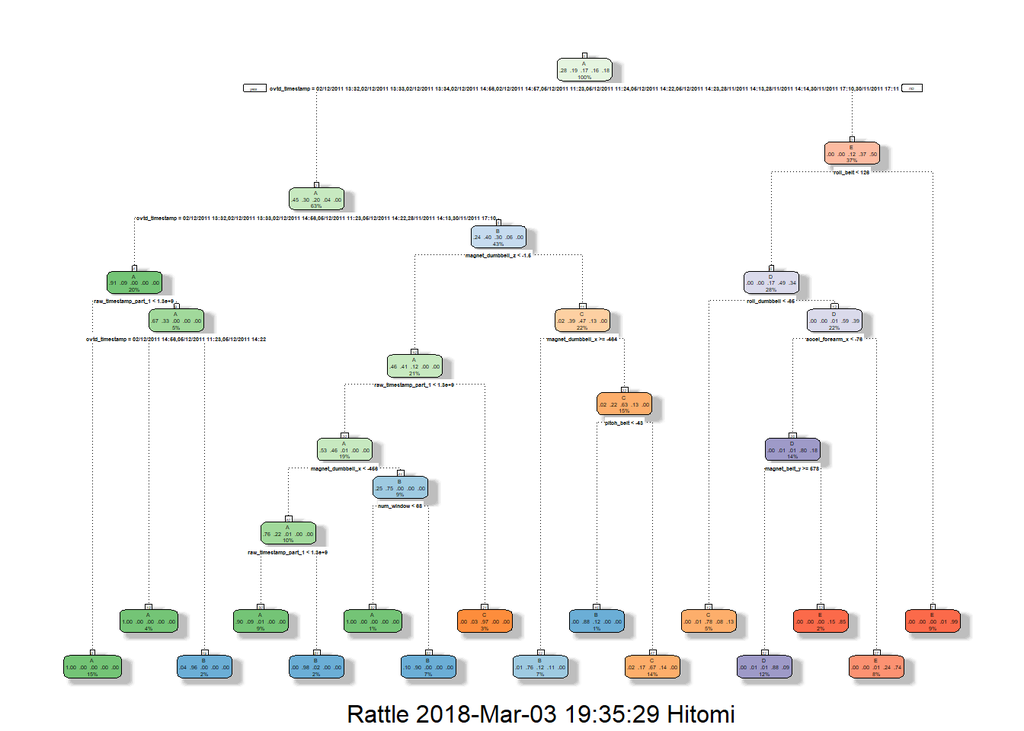

```r
modFitA1 <- rpart(classe ~ ., data=myTraining, method="class")
fancyRpartPlot(modFitA1)
```

```r
predictionsA1 <- predict(modFitA1, myTesting, type = "class")
cmtree <- confusionMatrix(predictionsA1, myTesting$classe); cmtree
```

```
## Confusion Matrix and Statistics
##
##           Reference
## Prediction    A    B    C    D    E
##          A 2158   67    6    2    0
##          B   53 1259   76   66    0
##          C   21  180 1265  212   59
##          D    0   12   10  803   82
##          E    0    0   11  203 1301
##
## Overall Statistics
##
##                Accuracy : 0.8649
##                  95% CI : (0.8571, 0.8724)
##     No Information Rate : 0.2845
##     P-Value [Acc > NIR] : < 2.2e-16
##
##                   Kappa : 0.829
##  Mcnemar's Test P-Value : NA
##
## Statistics by Class:
##
##                      Class: A Class: B Class: C Class: D Class: E
## Sensitivity            0.9668   0.8294   0.9247   0.6244   0.9022
## Specificity            0.9866   0.9692   0.9271   0.9841   0.9666
## Pos Pred Value         0.9664   0.8659   0.7283   0.8853   0.8587
## Neg Pred Value         0.9868   0.9595   0.9831   0.9304   0.9777
## Prevalence             0.2845   0.1935   0.1744   0.1639   0.1838
## Detection Rate         0.2750   0.1605   0.1612   0.1023   0.1658
## Detection Prevalence   0.2846   0.1853   0.2214   0.1156   0.1931
## Balanced Accuracy      0.9767   0.8993   0.9259   0.8043   0.9344
```

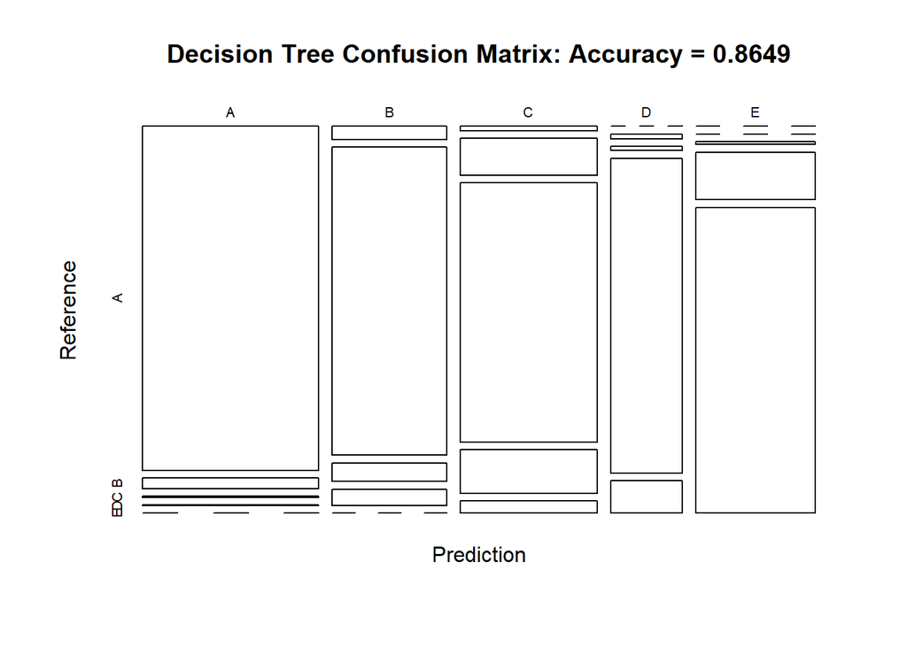

```r
plot(cmtree$table, col = cmtree$byClass, main = paste("Decision Tree Confusion Matrix: Accuracy =", round(cmtree$overall['Accuracy'], 5)))
```

## (2) Random Forests

```r
modFitB1 <- randomForest(classe ~ ., data=myTraining)
predictionB1 <- predict(modFitB1, myTesting, type = "class")
cmrf <- confusionMatrix(predictionB1, myTesting$classe); cmrf
```

```
## Confusion Matrix and Statistics
##
##           Reference
## Prediction    A    B    C    D    E
##          A 2231    0    0    0    0
##          B    1 1518    2    0    0
##          C    0    0 1365    3    0
##          D    0    0    1 1283    2
##          E    0    0    0    0 1440
##
## Overall Statistics
##
##                Accuracy : 0.9989
##                  95% CI : (0.9978, 0.9995)
##     No Information Rate : 0.2845
##     P-Value [Acc > NIR] : < 2.2e-16
##
##                   Kappa : 0.9985
##  Mcnemar's Test P-Value : NA
##
## Statistics by Class:
##
##                      Class: A Class: B Class: C Class: D Class: E
## Sensitivity            0.9996   1.0000   0.9978   0.9977   0.9986
## Specificity            1.0000   0.9995   0.9995   0.9995   1.0000
## Pos Pred Value         1.0000   0.9980   0.9978   0.9977   1.0000
## Neg Pred Value         0.9998   1.0000   0.9995   0.9995   0.9997
## Prevalence             0.2845   0.1935   0.1744   0.1639   0.1838
## Detection Rate         0.2843   0.1935   0.1740   0.1635   0.1835
## Detection Prevalence   0.2843   0.1939   0.1744   0.1639   0.1835
## Balanced Accuracy      0.9998   0.9998   0.9987   0.9986   0.9993
```

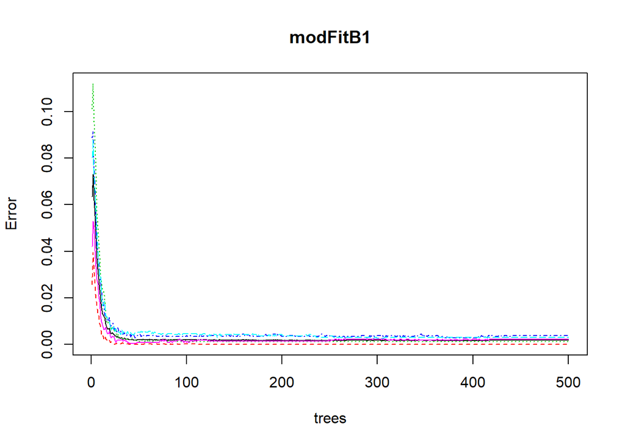

```r
plot(modFitB1)
```

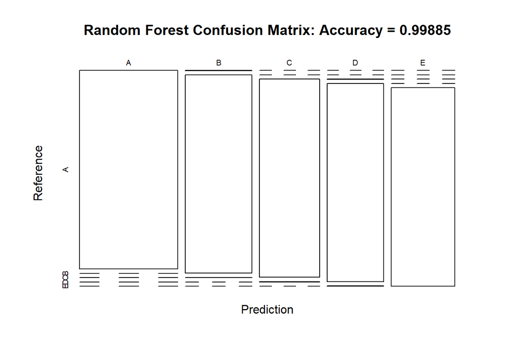

```r
plot(cmrf$table, col = cmtree$byClass, main = paste("Random Forest Confusion Matrix: Accuracy =", round(cmrf$overall['Accuracy'], 5)))
```

Because the prediction with random forests gave a better accurary than the prediction with decision tree, we eventually chose the prediction model built with random forests. The expected out-of-sample error is 0.0011471.